# VPC - meropenem PK model

Metrum Research Group, LLC

```r
source("src/global.R")
source("src/functions.R")
library(dplyr)
library(mrgsolve)
library(readr)
library(magrittr)
library(ggplot2)
library(parallel)
```

# Introduction

- “Population Pharmacokinetic Analysis and Dosing Regimen Optimization of Meropenem in Adult Patients”
  - Li et al. J Clin Pharmacol 2006
- Meropenem is broad-spectrum carbapenem antibiotic
  - Efficacy related to time above MIC
- IV dosing every 8 hours by infusion or bolus
  - bolus over 3 to 5 minutes
  - infusion over 15 to 30 minutes
- Authors are interested in seeing if a longer infusion duration can increase time above MIC

# Helper functions

```r
qt <- function(x,y) unname(quantile(x,prob=y/100))
lo <- function(x) qt(x,5)
hi <- function(x) qt(x,95)
med <- function(x) qt(x,50)
loci <- function(x) qt(x,2.5)
hici <- function(x) qt(x,97.5)
col1 <- "steelblue"
col2 <- "firebrick"
```

# Read and fix up the data set

```r
data <-
  read_csv("data/Simulated_DatasetMeropenem.csv", na = '.')  %>%
  mutate(CMT=1, DUR = AMT/RATE)
```

Derive a column that describes the infusion duration for each subject

```r
data %<>%
  group_by(ID) %>%
  mutate(DUR = first(DUR[!is.na(AMT)])) %>%
  ungroup

data <- data %>% mutate(DUR = round(DUR,1))
```

Look at distinct values of `CMT`, `EVID`, `DUR` in `data`

```r
count(data,CMT,EVID,DUR)
```

```
. # A tibble: 4 x 4
.     CMT  EVID   DUR     n
.   <dbl> <int> <dbl> <int>
. 1     1     0   0.5   280
. 2     1     0   3     273
. 3     1     1   0.5    40
. 4     1     1   3      39
```

Derive two data frames

- One with observations only
- One with doses only

```r
obs <- filter(data, EVID==0)
head(obs)
```

```
. # A tibble: 6 x 13
.      ID  TIME GROUP     DV   MDV  EVID   AMT  RATE   AGE    WT  CLCR   CMT
.   <int> <dbl> <int>  <dbl> <int> <int> <int> <dbl> <dbl> <dbl> <int> <dbl>
. 1     1   0.5     1 31.1      NA     0    NA    NA  29.7  63.8    83     1
. 2     1   1       1 11.2      NA     0    NA    NA  29.7  63.8    83     1
. 3     1   2       1  6.21     NA     0    NA    NA  29.7  63.8    83     1
. 4     1   3       1  4.00     NA     0    NA    NA  29.7  63.8    83     1
. 5     1   4       1  2.33     NA     0    NA    NA  29.7  63.8    83     1
. 6     1   6       1  0.766    NA     0    NA    NA  29.7  63.8    83     1
. # ... with 1 more variable: DUR <dbl>
```

```r
dose <- filter(data, EVID==1)
```

Plot observed data

```
. Warning in self$trans$transform(x): NaNs produced
```

```
. Warning: Transformation introduced infinite values in continuous y-axis
```

```
. Warning: Removed 17 rows containing missing values (geom_point).
```

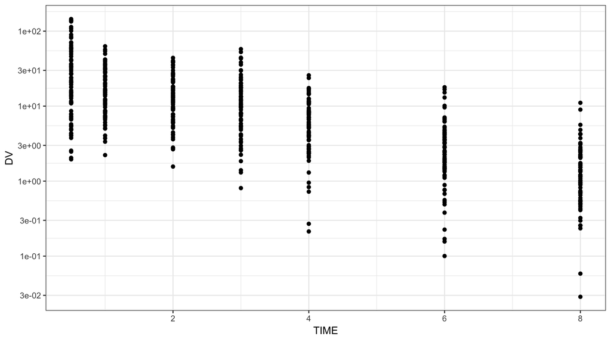

```r
ggplot(data=obs, aes(TIME,DV)) +
  geom_point() +
  scale_y_continuous(trans = "log", breaks = logbr())
```

Plot observed data by `DUR`

```
. Warning in self$trans$transform(x): NaNs produced
```

```
. Warning: Transformation introduced infinite values in continuous y-axis
```

```
. Warning: Removed 17 rows containing missing values (geom_point).
```

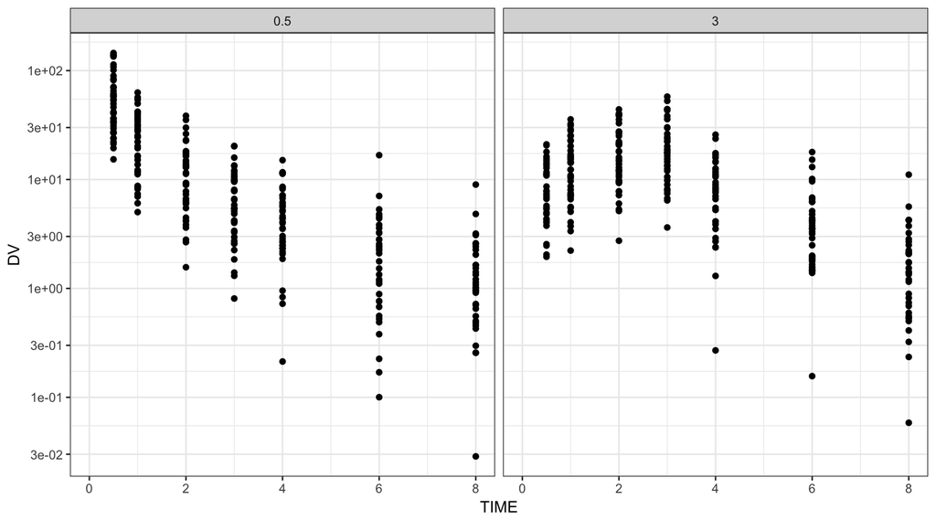

```r
ggplot(data=obs, aes(TIME,DV)) +
  geom_point() +
  scale_y_continuous(trans = "log", breaks = logbr()) +
  facet_wrap(~DUR) + xlim(0,8)
```

# Load the meropenem model

```r
mod <- mread("meropenem", "model")
see(mod)
```

```
.
. Model file:  meropenem.cpp
. [PROB]
. Meropenem PopPK
.
. https://www.ncbi.nlm.nih.gov/pubmed/16988206
.
. [SET] delta=0.1, end=8, req=""
.
. [PKMODEL] cmt = "CENT, PERIPH"
.
. [PARAM] @annotated
. WT   : 70 : Weight (kg)
. CLCR : 83 : Creatinine clearance (ml/min)
. AGE  : 35 : Age (years)
.
. [THETA] @annotated
.  1.50E+01 : Typical value of clearance (L/h)
.  1.27E+01 : Typical value of volume 1 (L)
.  1.52E+01 : Intercompartmental clearance (L/h)
.  1.24E+01 : Typical value of volume 2 (L)
. -4.47E-01 : AGE on CL
.  8.20E-01 : WT on V1
.  1.88E-01 : Proportional error standard deviation
.  4.76E-01 : Additive error standard deviation
.  6.20E-01 : CLCR on CL
.
. [MAIN]
.
. double TVCL     = THETA1;
. double TVV1     = THETA2;
. double TVQ      = THETA3;
. double TVV2     = THETA4;
. double CL_AGE   = THETA5;
. double V1_WT    = THETA6;
. double RUV_PROP = THETA7;
. double RUV_ADD  = THETA8;
. double CL_CLCR  = THETA9;
.
. double LOGTWT = log((WT/70.0));
```

[output cut: 12 more lines]

```
.
. [OMEGA] @annotated
. ECL : 8.84E-02 : ETA on CL
. EV1 : 9.76E-02 : ETA on V1
. EQ  : 1.03E-01 : ETA on Q
. EV2 : 7.26E-02 : ETA on V2
.
. [SIGMA] @annotated
. EP : 1 : Not used
.
. [TABLE]
. capture CC = (CENT/V1);
. double IPRED = CC;
. double W = sqrt((RUV_ADD*RUV_ADD)+ (RUV_PROP*RUV_PROP*IPRED*IPRED));
. capture Y = IPRED+W*EPS(1);
```

This model looks a little different because we got it off of DDMoRe model repository.

# Set up a simulation time grid for the VPC

We want - Hourly observations from time of first dose to 8 hours - Observations every 0.1 hours between 0 and 3 hours

```r
des1 <- tgrid(0,3.1,0.1)
des2 <- tgrid(0,8,1)
des <- c(des1,des2)
des
```

```
. start:  0  end:    3.1  delta:  0.1  offset: 0  min:    0   max:    3.1
. --------
. start:  0  end:    8  delta:  1  offset: 0  min:    0   max:    8
. --------
```

A function to do the (replicate) simulation

Arguments

- `i` the replicate number

Returns simulated data set

- time as in `des`
- `DUR` the infusion duration
- `TIME > 0` and `Y > 0`
- Labeled with replicate number

```r
simvpc <- function(i) {
  mod %>%
    data_set(dose) %>%
    carry_out(DUR) %>%
    obsonly %>%
    mrgsim(tgrid=des) %>%
    filter(TIME > 0 & Y > 0) %>%
    mutate(irep = i)
}
```

Simulate

- 100 iterations
- Use mclapply
- Bind into a single data frame

```r
niter <- 100
out <- mclapply(1:niter, mc.cores=8, simvpc) %>% bind_rows
```

# Summarize simulated data

```r
sum1 <-
  out %>%
  filter(Y > 0) %>%
  group_by(DUR,irep,TIME) %>%
  summarise(med=med(Y), lo=lo(Y), hi=hi(Y), N=n())
```

```r
sum2 <-
  sum1 %>%
  group_by(DUR,TIME) %>%
  summarise(medlo = loci(med), medmed = med(med), medhi = hici(med),
            lolo =  loci(lo),  lomed  = med(lo),  lohi  = hici(lo),
            hilo =  loci(hi),  himed  = med(hi),  hihi  = hici(hi))
```

```r
p1 <-
  ggplot(data=sum2) +
  geom_ribbon(aes(TIME,ymin=medlo, ymax = medhi),alpha=0.3,fill=col1) +
  geom_ribbon(aes(TIME,ymin=lolo, ymax=lohi),alpha=0.3,fill=col1) +
  geom_ribbon(aes(TIME,ymin=hilo, ymax=hihi),alpha=0.3,fill=col1) +
  geom_point(data=obs, aes(TIME,DV),col=col2) +
  geom_line(aes(TIME,y=medmed), lwd=1,col=col1) +
  geom_line(aes(TIME,y=lomed), lwd=1,col=col1) +
  geom_line(aes(TIME,y=himed), lwd=1,col=col1) +
  scale_y_continuous(trans="log", breaks=10^seq(-5,5)) +
  facet_wrap(~DUR)
```

```r
p1
```

```
. Warning in self$trans$transform(x): NaNs produced
```

```
. Warning: Transformation introduced infinite values in continuous y-axis
```

```
. Warning: Removed 17 rows containing missing values (geom_point).
```

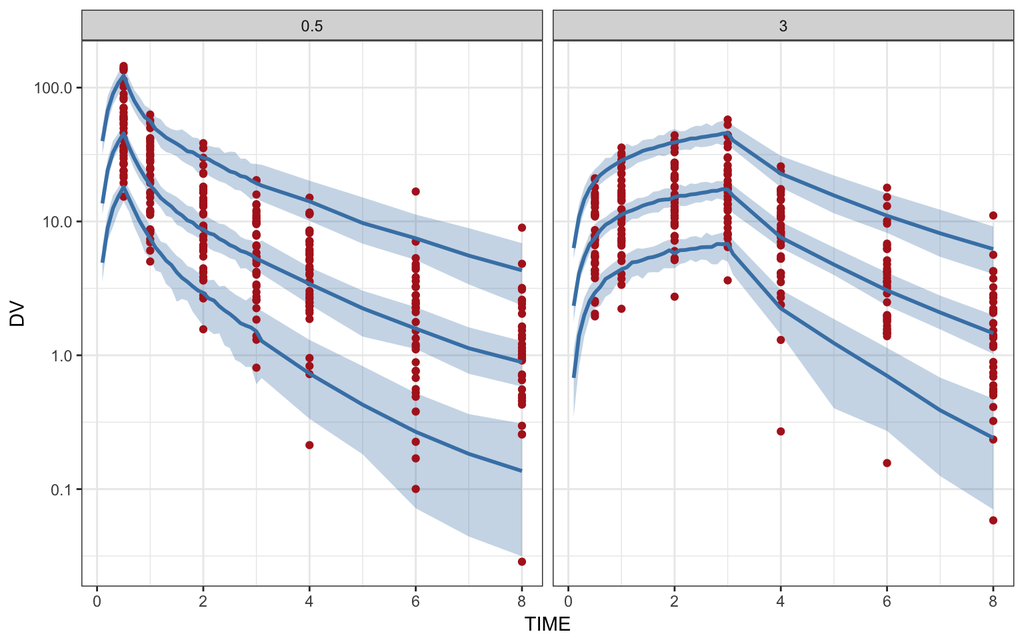

# Summarize observed data and add to plot

```r
obs1 <-
  obs %>%
  filter(DV > 0) %>%
  group_by(DUR,TIME) %>%
  summarise(med=med(DV), lo=lo(DV), hi=hi(DV), N=n())
```

```
. Warning in self$trans$transform(x): NaNs produced
```

```
. Warning: Transformation introduced infinite values in continuous y-axis
```

```
. Warning: Removed 17 rows containing missing values (geom_point).
```

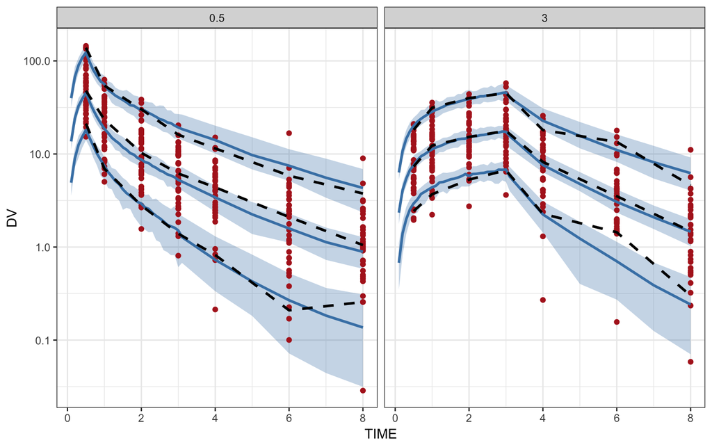

```r
p1 +
  geom_line(data=obs1,aes(TIME,y=med),lty=2, lwd=1) +
  geom_line(data=obs1,aes(TIME,y=lo), lty=2, lwd=1) +
  geom_line(data=obs1,aes(TIME,y=hi), lty=2, lwd=1)
```